# Seleção do período de análise dados das EMA do INMET

Jônatan Tatsch

14 setembro, 2017

# Introdução

A definição do período para análise das séries de dados de uma rede de estações meteorológicas automáticas (EMAs) segue critérios baseados na homogeneidade espacial das EMAs, na quantidade de dados mínima. Como critério inicial serão selecionadas estações meteorológicas automáticas (EMA) com pelo menos 4 anos de dados (podem ser descontínuos).

As etapas para seleção do período são:

- regularizar as séries temporais de cada EMA para garantir que todas tenham 24 h em cada dia e 365 (ou 366 dias, se ano bissexto) em cada ano
- determinar o período de dados de cada EMA (n° de anos)
- quantificar o número de dados válidos (não faltantes) para cada EMA

# Pacotes, funções e pré-configurações

Carregando pacotes necessários.

```r
# limpa espaço de trabalho
rm(list = ls())
# carrega pacotes necessários
pacotes <- c("knitr", "tidyverse", "lubridate", "openair", "stringr",
             "magrittr", "padr")
easypackages::libraries(pacotes)
# configura chuncks
# carrega scripts necessários
source("../R/gaps.R")
source("../R/utils.R")
source("../R/gg_bubble.R")
source("../R/complete_dates.R")
```

Os dados são armazenados usando o Tempo Universal Coordenado [UTC](https://pt.wikipedia.org/wiki/Tempo_Universal_Coordenado). Portanto, podemos definir esse horário como padrão nessa sessão do R. Assim qualquer conversão ou operação com datas e horários usando objetos [POSIX](https://stat.ethz.ch/R-manual/R-devel/library/base/html/DateTimeClasses.html) serão realizadas em UTC.

```r
# definindo globalmente tz = "UTC"
Sys.setenv(TZ = "UTC")
```

# Dados brutos

## Informações das EMAs (metadados)

Informações como as coordenadas de localização, altitude, nome e código das EMAs foram extraídas do cabeçalho contido no arquivo excel com os dados de cada EMA. Entretanto, notou-se que em alguns casos houve erro de digitação das coordenadas quando comparadas aquelas disponíveis no site do INMET.

```r
# metadados do INMET corrigidos e atualizados.(see R/aws-inmet-metadata.R)
tar_info <- readRDS("../data/info-inmet-sul.rds")
  tar_info
```

| site | state | name | lat | lon | alt | start |
| --- | --- | --- | --- | --- | --- | --- |
| B803 | PR | Campina Da Lagoa | -24.57086 | -52.80026 | 598 | 2016-08-04 |
| A819 | PR | Castro | -24.78695 | -49.99927 | 994 | 2006-07-09 |
| A869 | PR | Cidade Gaúcha | -23.35916 | -52.93191 | 366 | 2008-03-10 |
| A876 | PR | Clevelândia | -26.41720 | -52.34874 | 966 | 2008-05-16 |
| B806 | PR | Colombo | -25.32246 | -49.15773 | 950 | 2016-05-28 |
| A807 | PR | Curitiba | -25.44869 | -49.23060 | 923 | 2003-01-28 |
| A849 | PR | Diamante Do Norte | -22.63937 | -52.89016 | 368 | 2008-03-08 |
| A843 | PR | Dois Vizinhos | -25.69906 | -53.09527 | 546 | 2007-03-29 |
| A846 | PR | Foz Do Iguaçu | -25.60183 | -54.48307 | 235 | 2008-02-15 |
| A875 | PR | General Carneiro | -26.39847 | -51.35367 | 1009 | 2008-04-10 |

[output cut: 81 more lines]

## Dados meteorológicos

```r
tar_data <- readRDS("../data/data-raw-inmet-sul-20000922-20161231.rds") %>%
  select(site:tair, tmin, tmax, prec, p, rg)
glimpse(tar_data)
```

```
Observations: 6,747,744
Variables: 8
$ site <chr> "A807", "A807", "A807", "A807", "A807", "A807", "A807", "A807"...
$ date <dttm> 2003-01-28 00:00:00, 2003-01-28 01:00:00, 2003-01-28 02:00:00...
$ tair <dbl> NA, NA, NA, NA, NA, NA, NA, NA, NA, NA, NA, NA, NA, NA, NA, NA...
$ tmin <dbl> NA, NA, NA, NA, NA, NA, NA, NA, NA, NA, NA, NA, NA, NA, NA, NA...
$ tmax <dbl> NA, NA, NA, NA, NA, NA, NA, NA, NA, NA, NA, NA, NA, NA, NA, NA...
$ prec <dbl> NA, NA, NA, NA, NA, NA, NA, NA, NA, NA, NA, NA, NA, NA, NA, NA...
$ p    <dbl> NA, NA, NA, NA, NA, NA, NA, NA, NA, NA, NA, NA, NA, NA, NA, NA...
$ rg   <dbl> NA, NA, NA, NA, NA, NA, NA, NA, NA, NA, NA, NA, NA, NA, NA, NA...
```

# Dados temporalmente consistentes

Os dados podem conter falhas temporais. Isso implica que podem haver saltos temporais nos dados. Para garantir que os dados fiquem consitentes temporal (cada estação com dias contendo 24 horas e anos com 365 ou 366 dias) faz-se o preenchimento dos horários faltantes com as datas adequadas e os valores das variáveis recebem `NA`.

```r
# verificando intervalo de tempo
time_step <- tar_data %>%
  filter(., site == "A801") %>%
  select(date) %$%
  get_interval(date)
time_step
```

```
[1] "hour"
```

```r
nrow(tar_data)
```

```
[1] 6747744
```

```r
# cada site com um perído de dados diferente
table(tar_data$site)
```

```
  A801   A802   A803   A804   A805   A806   A807   A808   A809   A810   A811
142680 132600 132360   4416 132144 122232 122088  92064  89952  88800  87120
  A812   A813   A814   A815   A816   A817   A818   A819   A820   A821   A822
 92304  89880  75336  76464  72600  92064  91848  91896  88728  88608  87936
  A823   A824   A825   A826   A827   A828   A829   A830   A831   A832   A833
 89520  88776  89448  89952  87600  88560  89280  82848  80736  83088  69312
  A834   A835   A836   A837   A838   A839   A840   A841   A842   A843   A844
 77280  88656  87480  77472  88152  88512  88416  81384  86760  85584  86232
  A845   A846   A847   A848   A849   A850   A851   A852   A853   A854   A855
 83640  77832  85728  75288  77352  77400  83736  82752  84072  79344  80232
  A856   A857   A858   A859   A860   A861   A862   A863   A864   A865   A866
 77568  77208  77136  77040  77496  77232  76968  77376  69192  18888  75264
  A867   A868   A869   A870   A871   A872   A873   A874   A875   A876   A878
 72408  57192  77232   5160  77496  50112  77184  50064  76032  75672  77232
  A879   A880   A881   A882   A883   A884   A886   A889   A894   A897   A899
 73272  76128  58680  37200  35520  27096   3432   6480   6480    912  77304
  B803   B804   B806
  3600   3528   4416
```

```r
#microbenchmark::microbenchmark(
tar_data_pad <- tar_data %>%
  filter(!is.na(date)) %>%
   ## pad é muito lento
   # pad(interval = time_step,
   #     group = "site",
   #     break_above = 20
   #     #start_val = min(tar_data$date),
   #     #end_val = max(tar_data$date)
   #     ) #%>%
  complete_dates(group = "site", time_step = "hours")
#, times = 1)
nrow(tar_data_pad)
```

```
[1] 12983880
```

```r
# verificaçao da padronizaçao temporal
table(tar_data_pad$site)
```

```
  A801   A802   A803   A804   A805   A806   A807   A808   A809   A810   A811
142680 142680 142680 142680 142680 142680 142680 142680 142680 142680 142680
  A812   A813   A814   A815   A816   A817   A818   A819   A820   A821   A822
142680 142680 142680 142680 142680 142680 142680 142680 142680 142680 142680
  A823   A824   A825   A826   A827   A828   A829   A830   A831   A832   A833
142680 142680 142680 142680 142680 142680 142680 142680 142680 142680 142680
  A834   A835   A836   A837   A838   A839   A840   A841   A842   A843   A844
142680 142680 142680 142680 142680 142680 142680 142680 142680 142680 142680
  A845   A846   A847   A848   A849   A850   A851   A852   A853   A854   A855
142680 142680 142680 142680 142680 142680 142680 142680 142680 142680 142680
  A856   A857   A858   A859   A860   A861   A862   A863   A864   A865   A866
142680 142680 142680 142680 142680 142680 142680 142680 142680 142680 142680
  A867   A868   A869   A870   A871   A872   A873   A874   A875   A876   A878
142680 142680 142680 142680 142680 142680 142680 142680 142680 142680 142680
  A879   A880   A881   A882   A883   A884   A886   A889   A894   A897   A899
142680 142680 142680 142680 142680 142680 142680 142680 142680 142680 142680
  B803   B804   B806
142680 142680 142680
```

```r
#range(tar_data_pad2$date)
```

# Seleção de EMAs

## Critério de disponibilidade mínima de observações

Antes de determinar o período de dados de cada EMA é preciso remover as EMAs que conhenham muitos (todos) dados faltantes. Isso geralmente ocorre para EMAs inseridas recentemente no conjunto de dados.

- Classificação das EMAs pela % de falhas

```r
# ranking de falhas das EMAs
rank_falt <- tar_data_pad %>%
  group_by(site) %>%
  summarise(N = n(),
            falt = n_NA(tair),
            falt_perc = percent_NA(tair)) %>%
  arrange(desc(falt_perc)) %>%
  # combinando com info para saber nome das EMAs
  left_join(select(tar_info, site, name), by = "site")
rank_falt
```

| site | N | falt | falt_perc | name |
| --- | --- | --- | --- | --- |
| A897 | 142680 | 141804 | 99.386039 | Cambará Do Sul |
| A886 | 142680 | 139264 | 97.605831 | Tupanciretã |
| B804 | 142680 | 139179 | 97.546257 | Laranjeiras Do Sul |
| A804 | 142680 | 139123 | 97.507009 | Santana Do Livramento |
| B803 | 142680 | 139104 | 97.493692 | Campina Da Lagoa |
| B806 | 142680 | 138265 | 96.905663 | Colombo |
| A870 | 142680 | 137608 | 96.445192 | Rancho Queimado |
| A894 | 142680 | 136263 | 95.502523 | Serafina Corrêa |
| A889 | 142680 | 136231 | 95.480095 | São Vicente Do Sul |
| A865 | 142680 | 123920 | 86.851696 | Lages |

[output cut: 81 more lines]

```r
not_informative <- rank_falt %>%
  filter(N == falt)
not_informative
```

| site | N | falt | falt_perc | name |
| --- | --- | --- | --- | --- |

Removendo EMAs sem dados.

```r
glimpse(tar_data_pad)
```

```
Observations: 12,983,880
Variables: 8
$ date <dttm> 2000-09-22, 2000-09-22, 2000-09-22, 2000-09-22, 2000-09-22, 2...
$ site <chr> "A801", "A802", "A803", "A804", "A805", "A806", "A807", "A808"...
$ tair <dbl> NA, NA, NA, NA, NA, NA, NA, NA, NA, NA, NA, NA, NA, NA, NA, NA...
$ tmin <dbl> NA, NA, NA, NA, NA, NA, NA, NA, NA, NA, NA, NA, NA, NA, NA, NA...
$ tmax <dbl> NA, NA, NA, NA, NA, NA, NA, NA, NA, NA, NA, NA, NA, NA, NA, NA...
$ prec <dbl> NA, NA, NA, NA, NA, NA, NA, NA, NA, NA, NA, NA, NA, NA, NA, NA...
$ p    <dbl> NA, NA, NA, NA, NA, NA, NA, NA, NA, NA, NA, NA, NA, NA, NA, NA...
$ rg   <dbl> NA, NA, NA, NA, NA, NA, NA, NA, NA, NA, NA, NA, NA, NA, NA, NA...
```

```r
# dados preenchidos e informativo
tar_data_pad_inf <- tar_data_pad %>%
  filter(! site %in% not_informative$site)
glimpse(tar_data_pad_inf)
```

```
Observations: 12,983,880
Variables: 8
$ date <dttm> 2000-09-22, 2000-09-22, 2000-09-22, 2000-09-22, 2000-09-22, 2...
$ site <chr> "A801", "A802", "A803", "A804", "A805", "A806", "A807", "A808"...
$ tair <dbl> NA, NA, NA, NA, NA, NA, NA, NA, NA, NA, NA, NA, NA, NA, NA, NA...
$ tmin <dbl> NA, NA, NA, NA, NA, NA, NA, NA, NA, NA, NA, NA, NA, NA, NA, NA...
$ tmax <dbl> NA, NA, NA, NA, NA, NA, NA, NA, NA, NA, NA, NA, NA, NA, NA, NA...
$ prec <dbl> NA, NA, NA, NA, NA, NA, NA, NA, NA, NA, NA, NA, NA, NA, NA, NA...
$ p    <dbl> NA, NA, NA, NA, NA, NA, NA, NA, NA, NA, NA, NA, NA, NA, NA, NA...
$ rg   <dbl> NA, NA, NA, NA, NA, NA, NA, NA, NA, NA, NA, NA, NA, NA, NA, NA...
```

## Critérios baseados no período de dados

### Período de dados

```r
tar_periods <- tar_data_pad_inf %>%
  group_by(site) %>%
  filter(!is.na(tair)) %>%
  summarise(start = as.Date(min(date)) # data inicial
           ,end = as.Date(max(date)) # data final
           ,period = round(time_length(end - start, unit = "year"), 1))  %>% # período
            # desagrupando por site
            ungroup() %>%
  arrange(desc(period)) %>%
  # combinando com info para saber nome das EMAs
  left_join(select(tar_info, site, name, state, lon, lat), by = "site")
tar_periods
```

| site | start | end | period | name | state | lon | lat |
| --- | --- | --- | --- | --- | --- | --- | --- |
| A801 | 2000-09-22 | 2016-12-31 | 16.3 | Porto Alegre | RS | -51.17477 | -30.05354 |
| A802 | 2001-11-17 | 2016-12-31 | 15.1 | Rio Grande | RS | -52.16774 | -32.07878 |
| A803 | 2001-11-26 | 2016-12-31 | 15.1 | Santa Maria | RS | -53.72047 | -29.72496 |
| A805 | 2001-12-05 | 2016-12-31 | 15.1 | Santo Augusto | RS | -53.79118 | -27.85434 |
| A806 | 2003-03-17 | 2016-12-31 | 13.8 | Florianópolis-São José | SC | -48.62010 | -27.60253 |
| A807 | 2003-03-17 | 2016-12-31 | 13.8 | Curitiba | PR | -49.23060 | -25.44869 |
| A808 | 2006-06-01 | 2016-12-31 | 10.6 | Torres | RS | -49.73326 | -29.35036 |
| A812 | 2006-06-22 | 2016-12-31 | 10.5 | Caçapava Do Sul | RS | -53.46705 | -30.54532 |
| A817 | 2006-07-02 | 2016-12-29 | 10.5 | Indaial | SC | -49.26798 | -26.91370 |
| A818 | 2006-07-11 | 2016-12-31 | 10.5 | Ivaí | PR | -50.85385 | -25.01076 |

[output cut: 81 more lines]

### Seleção de dados por período mínimo e ano inicial

As EMAs selecionadas devem ter um período de pelo menos 4 anos e baseado em trabalhos prévios devem começar em 2008.

```r
begin_year <- 2008
end_year <- 2016
period_thres <- 4
tar_data_sel <- tar_data_pad_inf %>%
  selectByDate(year = begin_year:end_year)
glimpse(tar_data_pad_inf)
```

```
Observations: 12,983,880
Variables: 8
$ date <dttm> 2000-09-22, 2000-09-22, 2000-09-22, 2000-09-22, 2000-09-22, 2...
$ site <chr> "A801", "A802", "A803", "A804", "A805", "A806", "A807", "A808"...
$ tair <dbl> NA, NA, NA, NA, NA, NA, NA, NA, NA, NA, NA, NA, NA, NA, NA, NA...
$ tmin <dbl> NA, NA, NA, NA, NA, NA, NA, NA, NA, NA, NA, NA, NA, NA, NA, NA...
$ tmax <dbl> NA, NA, NA, NA, NA, NA, NA, NA, NA, NA, NA, NA, NA, NA, NA, NA...
$ prec <dbl> NA, NA, NA, NA, NA, NA, NA, NA, NA, NA, NA, NA, NA, NA, NA, NA...
$ p    <dbl> NA, NA, NA, NA, NA, NA, NA, NA, NA, NA, NA, NA, NA, NA, NA, NA...
$ rg   <dbl> NA, NA, NA, NA, NA, NA, NA, NA, NA, NA, NA, NA, NA, NA, NA, NA...
```

```r
# EMAs com pelo menos 4 anos (sites selecionados)
sites_sel <- tar_periods %>%
  filter(period >= period_thres) %>%
  select(site) %>%
  pull()
sites_sel
```

```
 [1] "A801" "A802" "A803" "A805" "A806" "A807" "A808" "A812" "A817" "A818"
[11] "A819" "A809" "A813" "A826" "A823" "A825" "A829" "A810" "A820" "A821"
[21] "A824" "A828" "A835" "A838" "A839" "A840" "A822" "A827" "A811" "A836"
[31] "A842" "A843" "A844" "A847" "A851" "A853" "A830" "A845" "A852" "A831"
[41] "A832" "A841" "A855" "A854" "A846" "A834" "A837" "A849" "A850" "A856"
[51] "A857" "A858" "A859" "A860" "A861" "A862" "A863" "A869" "A871" "A873"
[61] "A878" "A899" "A815" "A875" "A880" "A814" "A848" "A866" "A876" "A879"
[71] "A867" "A816" "A833" "A864" "A881" "A868" "A872" "A874" "A882" "A883"
```

```r
length(sites_sel)
```

```
[1] 80
```

```r
# filtrar dados só com as EMAs do sites_sel
tar_data_sel <- filter(tar_data_sel, site %in% sites_sel)
glimpse(tar_data_sel)
```

```
Observations: 6,312,960
Variables: 8
$ date <dttm> 2008-01-01, 2008-01-01, 2008-01-01, 2008-01-01, 2008-01-01, 2...
$ site <chr> "A801", "A802", "A803", "A805", "A806", "A807", "A808", "A809"...
$ tair <dbl> 24.7, 23.3, 24.9, 24.1, 22.5, 20.6, 24.7, 26.3, 24.8, 21.7, 24...
$ tmin <dbl> 24.7, 23.3, 24.9, 24.1, 22.3, 20.5, 24.6, 26.2, 24.8, 21.7, 24...
$ tmax <dbl> 26.0, 23.8, 26.3, 25.2, 22.5, 20.7, 25.4, 28.1, 26.4, 22.5, 25...
$ prec <dbl> 0.0, 0.0, 0.0, 0.0, 0.2, 0.0, 0.0, 0.0, 0.0, 0.0, 0.0, 0.0, NA...
$ p    <dbl> 1006.9, 1011.3, 999.0, 954.7, 1011.9, 911.1, 1011.3, 1000.9, 9...
$ rg   <dbl> NA, NA, NA, NA, NA, NA, NA, NA, NA, NA, NA, NA, NA, NA, NA, NA...
```

Salvar dados selecionados pelos critérios de período mínimo de 4 anos e ano inicial 2008.

```r
# dados
file_data_sel <- paste0("tar-data-inmet-",
                        begin_year, "-",
                        end_year, "-",
                        period_thres, "yrs-",
                        "south.rds")
saveRDS(tar_data_sel, file = file.path("../output", file_data_sel))
# metadados
file_info_sel <- paste0("tar-info-inmet-",
                        begin_year, "-",
                        end_year, "-",
                        period_thres, "yrs-",
                        "south.rds")
tar_info_sel <- filter(tar_info, site %in% sites_sel)
tar_info_sel
```

| site | state | name | lat | lon | alt | start |
| --- | --- | --- | --- | --- | --- | --- |
| A819 | PR | Castro | -24.78695 | -49.99927 | 994 | 2006-07-09 |
| A869 | PR | Cidade Gaúcha | -23.35916 | -52.93191 | 366 | 2008-03-10 |
| A876 | PR | Clevelândia | -26.41720 | -52.34874 | 966 | 2008-05-16 |
| A807 | PR | Curitiba | -25.44869 | -49.23060 | 923 | 2003-01-28 |
| A849 | PR | Diamante Do Norte | -22.63937 | -52.89016 | 368 | 2008-03-08 |
| A843 | PR | Dois Vizinhos | -25.69906 | -53.09527 | 546 | 2007-03-29 |
| A846 | PR | Foz Do Iguaçu | -25.60183 | -54.48307 | 235 | 2008-02-15 |
| A875 | PR | General Carneiro | -26.39847 | -51.35367 | 1009 | 2008-04-10 |
| A824 | PR | Icaraíma | -23.39038 | -53.63593 | 381 | 2006-11-15 |
| A847 | PR | Ilha Do Mel | -25.49452 | -48.32604 | 4 | 2007-03-23 |

[output cut: 70 more lines]

```r
saveRDS(tar_info_sel, file = file.path("../output", file_info_sel))
```

Gráfico do período de dados.

```r
estados <- readRDS("../data/estados_sul.rds")
filter(tar_periods, site == "A825")
```

| site | start | end | period | name | state | lon | lat |
| --- | --- | --- | --- | --- | --- | --- | --- |
| A825 | 2006-10-19 | 2016-12-31 | 10.2 | Goioere | PR | -53.02861 | -24.185 |

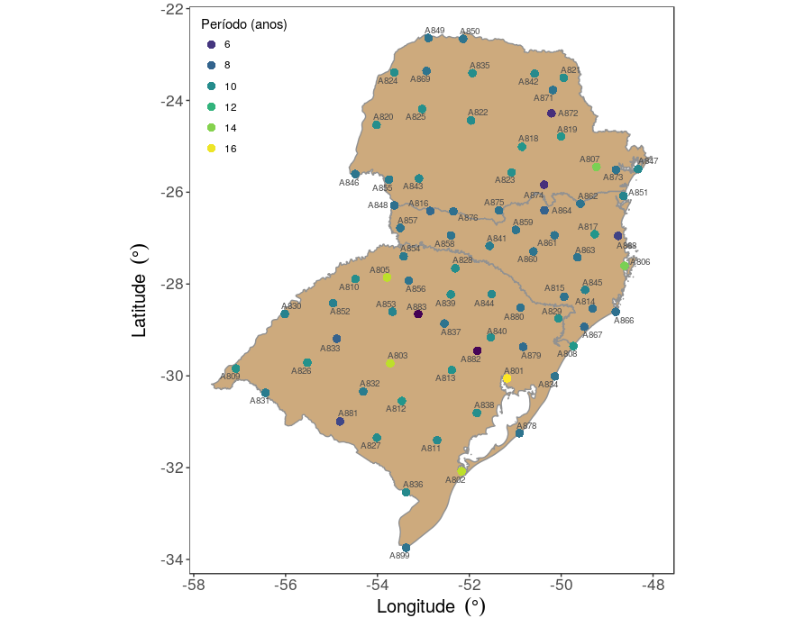

```r
gg_periodo <- gg_bubble(data =  filter(tar_periods, site %in% sites_sel)
                     #data = tar_periods
                     ,z = "period"
                     ,breaks = pretty(tar_periods$period, n = 10)
                     ,limites = estados
                     ,colors_z = viridis::viridis
                     ,color_fill = "burlywood3"
                     ,z_legend = "Período (anos)"
                     ,text_color = "gray30"
                     ,point_color = "transparent"
                     ,text_size = 2.6
                     ,point_size = 3
                     ,repel_min_seg_len = 2,
                     ,legend.justification = c(0,1)
                     ,legend.position = c(0.01, 0.99)
                     ,guide_type = "legend")
gg_periodo
```

```
Ignoring unknown parameters: binwidth, bins, pad
```

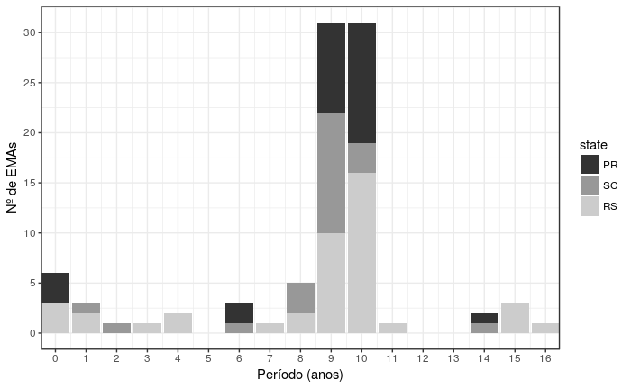

```r
ggplot(tar_periods,
       aes(x = round(period))) +
  #geom_histogram(aes(y = ..count../sum(..count..)), stat = "count") +
  geom_histogram(stat = "count", aes(fill = state)) +
  #viridis::scale_fill_viridis(discrete=TRUE, option = "inferno") +
  scale_fill_grey() +
  #scale_y_continuous(labels = scales::percent,
  #                   sec.axis = sec_axis(~. * sum(.))) +
  scale_x_continuous(breaks = scales::pretty_breaks(n = 15),
                     expand = c(0, 0)) +
  scale_y_continuous(breaks = scales::pretty_breaks(n = 12),
                     expand = c(0.05, 0.05)) +
  labs(x = "Período (anos)", y = "Nº de EMAs") +
  theme_bw()
```

# Disponibilidade de dados

```r
tar_gaps <- tar_data_sel %>%
  group_by(site) %>%
  dplyr::summarise(# % de dados faltantes
                   missing = round(percent_NA(tair), 1),
                   valid = 100 - missing,
                   #long_valid = length(na.contiguous(tair)),
                   long_valid = longest_gap(tair, reverse = TRUE),
                   # tamnho da falha mais longa
                   long_gap = longest_gap(tair),
                   #data de início da maior falha
                   date_slg = date_longest_gap(tair, date),
                   date_slv = date_longest_gap(tair, date, reverse = TRUE)
                   )  %>%
  # desagrupando por site
  ungroup() %>%
  # combinando com a tabela de informações das EMA
  left_join(tar_periods, by = "site") %>%
  arrange_vars(c("name" = 2, "period" = 3)) %>%
  arrange(desc(missing))
tar_gaps
```

| site | name | period | missing | valid | long_valid | long_gap | date_slg | date_slv | start | end | state | lon | lat |
| --- | --- | --- | --- | --- | --- | --- | --- | --- | --- | --- | --- | --- | --- |
| A883 | Ibirubá | 4.1 | 58.5 | 41.5 | 8908 | 43413 | 2008-01-01 00:00:00 | 2015-10-13 14:00:00 | 2012-12-13 | 2016-12-31 | RS | -53.11188 | -28.65346 |
| A882 | Teutônia | 4.2 | 54.5 | 45.5 | 6988 | 41820 | 2008-01-01 00:00:00 | 2013-08-26 09:00:00 | 2012-10-08 | 2016-12-31 | RS | -51.82428 | -29.45033 |
| A872 | Ventania | 5.7 | 39.6 | 60.4 | 15240 | 28885 | 2008-01-01 00:00:00 | 2015-01-22 18:00:00 | 2011-04-18 | 2016-12-31 | PR | -50.21015 | -24.28039 |
| A874 | São Mateus Do Sul | 5.7 | 37.7 | 62.3 | 11361 | 28891 | 2008-01-01 00:00:00 | 2015-01-22 18:00:00 | 2011-04-18 | 2016-12-31 | PR | -50.36899 | -25.83560 |
| A881 | Dom Pedrito | 6.7 | 31.5 | 68.5 | 9369 | 20345 | 2008-01-01 00:00:00 | 2011-03-30 20:00:00 | 2010-04-27 | 2016-12-31 | RS | -54.81527 | -30.99247 |
| A868 | Itajaí | 6.5 | 28.0 | 72.0 | 17202 | 21762 | 2008-01-01 00:00:00 | 2014-04-07 13:00:00 | 2010-06-25 | 2016-12-31 | SC | -48.76203 | -26.95092 |
| A848 | Dionísio Cerqueira | 8.6 | 18.3 | 81.7 | 9650 | 3624 | 2008-01-01 00:00:00 | 2015-09-12 16:00:00 | 2008-05-31 | 2016-12-31 | SC | -53.63311 | -26.28656 |
| A847 | Ilha Do Mel | 9.8 | 17.0 | 83.0 | 11760 | 3229 | 2010-04-07 03:00:00 | 2011-04-27 15:00:00 | 2007-03-23 | 2016-12-31 | PR | -48.32604 | -25.49452 |
| A850 | Paranapoema | 8.8 | 16.4 | 83.6 | 12373 | 9219 | 2009-02-27 09:00:00 | 2013-06-25 20:00:00 | 2008-03-04 | 2016-12-31 | PR | -52.13453 | -22.65827 |
| A833 | Santiago | 7.9 | 15.0 | 85.0 | 10033 | 9613 | 2008-01-01 00:00:00 | 2013-07-19 21:00:00 | 2009-02-04 | 2016-12-31 | RS | -54.88565 | -29.19160 |

[output cut: 70 more lines]

```r
# convertendo max duração contínua de horas faltantes ou válidas para dias
tar_gaps <- tar_gaps %>%
  mutate(long_valid = round(time_length(hours(long_valid), unit = "day")),
         long_gap = round(time_length(hours(long_valid), unit = "day")))
tar_gaps
```

| site | name | period | missing | valid | long_valid | long_gap | date_slg | date_slv | start | end | state | lon | lat |
| --- | --- | --- | --- | --- | --- | --- | --- | --- | --- | --- | --- | --- | --- |
| A883 | Ibirubá | 4.1 | 58.5 | 41.5 | 371 | 15 | 2008-01-01 00:00:00 | 2015-10-13 14:00:00 | 2012-12-13 | 2016-12-31 | RS | -53.11188 | -28.65346 |
| A882 | Teutônia | 4.2 | 54.5 | 45.5 | 291 | 12 | 2008-01-01 00:00:00 | 2013-08-26 09:00:00 | 2012-10-08 | 2016-12-31 | RS | -51.82428 | -29.45033 |
| A872 | Ventania | 5.7 | 39.6 | 60.4 | 635 | 26 | 2008-01-01 00:00:00 | 2015-01-22 18:00:00 | 2011-04-18 | 2016-12-31 | PR | -50.21015 | -24.28039 |
| A874 | São Mateus Do Sul | 5.7 | 37.7 | 62.3 | 473 | 20 | 2008-01-01 00:00:00 | 2015-01-22 18:00:00 | 2011-04-18 | 2016-12-31 | PR | -50.36899 | -25.83560 |
| A881 | Dom Pedrito | 6.7 | 31.5 | 68.5 | 390 | 16 | 2008-01-01 00:00:00 | 2011-03-30 20:00:00 | 2010-04-27 | 2016-12-31 | RS | -54.81527 | -30.99247 |
| A868 | Itajaí | 6.5 | 28.0 | 72.0 | 717 | 30 | 2008-01-01 00:00:00 | 2014-04-07 13:00:00 | 2010-06-25 | 2016-12-31 | SC | -48.76203 | -26.95092 |
| A848 | Dionísio Cerqueira | 8.6 | 18.3 | 81.7 | 402 | 17 | 2008-01-01 00:00:00 | 2015-09-12 16:00:00 | 2008-05-31 | 2016-12-31 | SC | -53.63311 | -26.28656 |
| A847 | Ilha Do Mel | 9.8 | 17.0 | 83.0 | 490 | 20 | 2010-04-07 03:00:00 | 2011-04-27 15:00:00 | 2007-03-23 | 2016-12-31 | PR | -48.32604 | -25.49452 |
| A850 | Paranapoema | 8.8 | 16.4 | 83.6 | 516 | 22 | 2009-02-27 09:00:00 | 2013-06-25 20:00:00 | 2008-03-04 | 2016-12-31 | PR | -52.13453 | -22.65827 |
| A833 | Santiago | 7.9 | 15.0 | 85.0 | 418 | 17 | 2008-01-01 00:00:00 | 2013-07-19 21:00:00 | 2009-02-04 | 2016-12-31 | RS | -54.88565 | -29.19160 |

[output cut: 70 more lines]

```r
file_gaps <- paste0("tar-gaps-inmet-",
                        begin_year, "-",
                        end_year, "-",
                        period_thres, "yrs-",
                        "south.rds")
saveRDS(tar_gaps, file = file.path("../output", file_gaps))
```

*Porcentagem de observações por mês*

```r
table(tar_data_sel$site)
```

```
 A801  A802  A803  A805  A806  A807  A808  A809  A810  A811  A812  A813  A814
78912 78912 78912 78912 78912 78912 78912 78912 78912 78912 78912 78912 78912
 A815  A816  A817  A818  A819  A820  A821  A822  A823  A824  A825  A826  A827
78912 78912 78912 78912 78912 78912 78912 78912 78912 78912 78912 78912 78912
 A828  A829  A830  A831  A832  A833  A834  A835  A836  A837  A838  A839  A840
78912 78912 78912 78912 78912 78912 78912 78912 78912 78912 78912 78912 78912
 A841  A842  A843  A844  A845  A846  A847  A848  A849  A850  A851  A852  A853
78912 78912 78912 78912 78912 78912 78912 78912 78912 78912 78912 78912 78912
 A854  A855  A856  A857  A858  A859  A860  A861  A862  A863  A864  A866  A867
78912 78912 78912 78912 78912 78912 78912 78912 78912 78912 78912 78912 78912
 A868  A869  A871  A872  A873  A874  A875  A876  A878  A879  A880  A881  A882
78912 78912 78912 78912 78912 78912 78912 78912 78912 78912 78912 78912 78912
 A883  A899
78912 78912
```

```r
# porcentagem mensal de dados válidos com o periodo nao normalizado
records_month <- tar_data_sel %>%
  select(date, site, tair, prec) %>%
  group_by(site) %>%
  openair::timeAverage(avg.time = "month",
                       statistic = "data.cap",
                       type = "site") %>%
  #mutate(date = as.Date(date)) %>%
  ungroup() %>%
  mutate(x = as.numeric(date))
```

```
|======================================================|100% ~0 s remaining
```

```r
records_month
```

| site | date | tair | prec | x |
| --- | --- | --- | --- | --- |
| A801 | 2008-01-01 | 87.0967742 | 87.0967742 | 1199145600 |
| A801 | 2008-02-01 | 99.4252874 | 99.4252874 | 1201824000 |
| A801 | 2008-03-01 | 100.0000000 | 100.0000000 | 1204329600 |
| A801 | 2008-04-01 | 100.0000000 | 100.0000000 | 1207008000 |
| A801 | 2008-05-01 | 97.0430108 | 88.7096774 | 1209600000 |
| A801 | 2008-06-01 | 99.5833333 | 99.5833333 | 1212278400 |
| A801 | 2008-07-01 | 100.0000000 | 100.0000000 | 1214870400 |
| A801 | 2008-08-01 | 100.0000000 | 100.0000000 | 1217548800 |
| A801 | 2008-09-01 | 100.0000000 | 100.0000000 | 1220227200 |
| A801 | 2008-10-01 | 100.0000000 | 100.0000000 | 1222819200 |

[output cut: 990 more lines]

```r
# ordem dos sites por disponibilidade
sites_ord <- records_month %>%
  group_by(site) %>%
  summarise(disp = mean(tair, na.rm = TRUE)) %>%
  arrange(desc(disp)) %>%
  #select(site) %>%
  pull(site) %>%  as.character()
#sites_ord
# dados para plot
records_month_plot <- records_month %>%
  mutate(tair = ifelse(tair > 0, tair, NA),
         prec = ifelse(prec > 0, prec, NA),
         site = ordered(site, levels = sites_ord))
levels(records_month_plot$site)
```

```
 [1] "A839" "A801" "A806" "A853" "A854" "A860" "A811" "A821" "A819" "A803"
[11] "A841" "A812" "A836" "A844" "A840" "A813" "A817" "A859" "A827" "A832"
[21] "A808" "A818" "A871" "A837" "A809" "A829" "A831" "A828" "A826" "A876"
[31] "A834" "A820" "A856" "A863" "A873" "A838" "A815" "A880" "A858" "A814"
[41] "A857" "A862" "A823" "A830" "A845" "A802" "A825" "A878" "A899" "A879"
[51] "A875" "A855" "A835" "A843" "A851" "A822" "A846" "A805" "A867" "A824"
[61] "A861" "A807" "A866" "A842" "A852" "A816" "A849" "A810" "A869" "A833"
[71] "A864" "A850" "A847" "A848" "A868" "A881" "A874" "A872" "A882" "A883"
```

**Gráficos da disponibilidade de dados.**

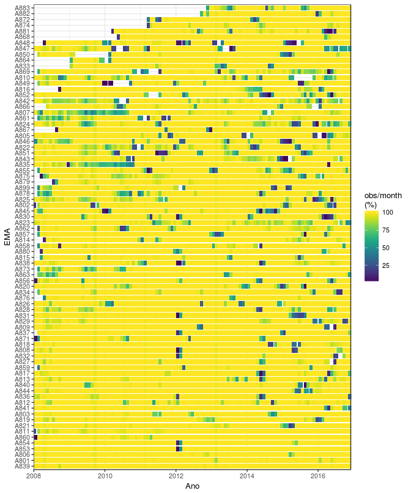

```r
ggp <- ggplot(aes(x = date,
                  y = site),
              data = records_month_plot) +
              #data = records_month_plot %>% filter(year(date)==2016)) +
  #geom_tile(aes(fill = avail)) +
  #geom_raster(aes(fill = avail)) +
  geom_point(aes(colour = tair), shape=15, size = 2.6) +
  labs(x = "Ano", y = "EMA") +
  #ylim(rev(levels(records_month_plot$site)))+
  #scale_y_discrete(expand = c(0, 0)
                   #labels = yl_labels
  #                 ) +
   #scale_y_discrete(position = c("right"),
    #                labels = yr_labels, ) +
  scale_x_datetime(expand = c(0, 0),
                   #breaks = scales::date_breaks(width = "1 year"),
                   #minor_breaks = scales::date_breaks(width = "6 months"),
                   #labels = scales::date_format("%Y")
                   ) +
  scale_colour_gradientn("obs/month\n(%)",
                         colours = viridis::viridis(n = 256),
                         na.value = NA) +
#  scale_fill_gradientn("records/month\n(%)",
#                       colours = viridis::viridis(n= 256),
#                       na.value = NA)+
  theme_bw() +
  theme(text = element_text(size=10)
        #aspect.ratio = 1
        #aspect.ratio = 2 / (1 + sqrt(5))
        #aspect.ratio = (1 + sqrt(5))/ 2
        )
ggp
```

# > dados de julho de 2016 não inclusos no conj de dados

```r
estados <- readRDS("../data/estados_sul.rds")
filter(tar_gaps, site == "A825")
```

| site | name | period | missing | valid | long_valid | long_gap | date_slg | date_slv | start | end | state | lon | lat |
| --- | --- | --- | --- | --- | --- | --- | --- | --- | --- | --- | --- | --- | --- |
| A825 | Goioere | 10.2 | 7.9 | 92.1 | 576 | 24 | 2015-12-04 05:00:00 | 2013-06-25 20:00:00 | 2006-10-19 | 2016-12-31 | PR | -53.02861 | -24.185 |

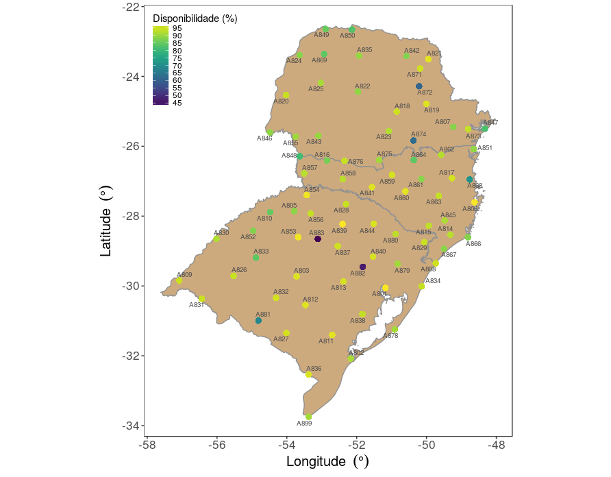

```r
gg_disp <- gg_bubble(#data =  filter(tar_gaps, site %in% sites_sel)
                     data = tar_gaps
                     ,z = "valid"
                     ,breaks = c(pretty(tar_gaps$valid, n = 10),105)
                     ,limites = estados
                     ,colors_z = viridis::viridis
                     ,color_fill = "burlywood3"
                     ,z_legend = "Disponibilidade (%)"
                     ,text_color = "gray30"
                     ,point_color = "transparent"
                     ,text_size = 2.6
                     ,point_size = 3
                     ,repel_min_seg_len = 2,
                     ,legend.justification = c(0,1)
                     ,legend.position = c(0.01, 0.99)
                     ,guide_type = "colourbar"
                     )
gg_disp
```

```r
range(tar_gaps$valid)
```

```
[1] 41.5 99.8
```

```
Ignoring unknown parameters: binwidth, bins, pad
```

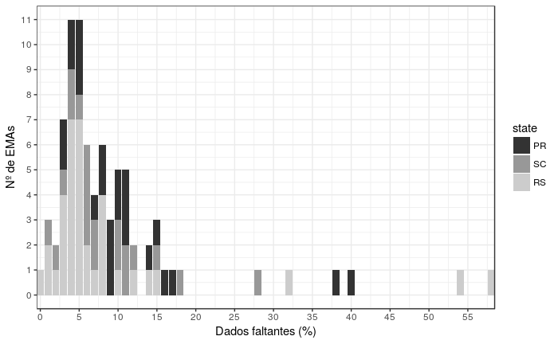

```r
ggplot(tar_gaps,
       aes(x = round(missing))) +
  #geom_histogram(aes(y = ..count../sum(..count..)), stat = "count") +
  geom_histogram(stat = "count", aes(fill = state)) +
  #viridis::scale_fill_viridis(discrete=TRUE, option = "inferno") +
  scale_fill_grey() +
  #scale_y_continuous(labels = scales::percent,
  #                   sec.axis = sec_axis(~. * sum(.))) +
  scale_y_continuous(breaks = scales::pretty_breaks(n = 10)) +
  scale_x_continuous(breaks = scales::pretty_breaks(n = 12),
                     expand = c(0, 0)) +
  labs(x = "Dados faltantes (%)", y = "Nº de EMAs") +
  theme_bw()
```

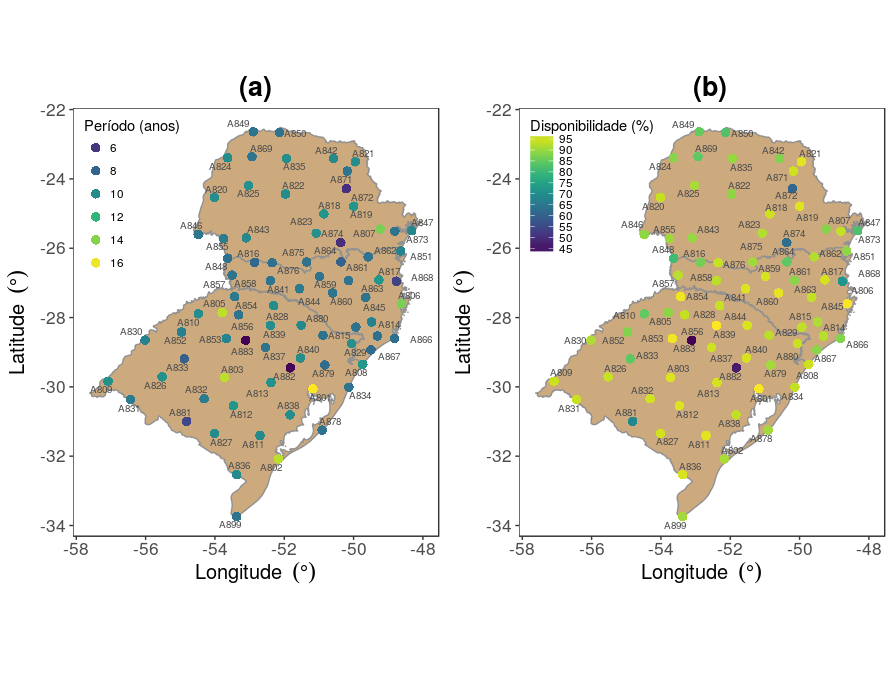

```r
cowplot::plot_grid(gg_periodo,
                   gg_disp,
                   labels = c("(a)", "(b)"),
                   vjust = 4.8,
                   hjust = -7.25,
                   align = "h",
                   label_size = 20)
```

# Arquivos gerados para análises futuras

- arquivo de metadados
  - `output/tar-info-inmet-2008-2016-4yrs-south.rds`
- arquivo de dados meteorológicos
  - `output/tar-data-inmet-2008-2016-4yrs-south.rds`